# LOTB1

PIDS

2024-04-26

Importer les librairies nécessaires :

```r
library(tseries)
library(forecast)
library(astsa)
library(lmtest)
```

Importer les données:

```r
df <- read.csv("C:/Users/yassi/Downloads/HOUSTNENSA.csv")
```

#PARTIE1: Analyse statistique et graphique d’une série temporelle

```r
if (any(is.na(df))) {
  print("Il y a des valeurs manquantes dans le jeu de données.")
} else {
  print("Il n'y a pas de valeurs manquantes dans le jeu de données.")
}
```

```
## [1] "Il n'y a pas de valeurs manquantes dans le jeu de données."
```

```r
df$DATE <- as.Date(df$DATE)
```

```r
df <- ts( df$HOUSTNENSA,start =1986,end = 2019,frequency = 12)
```

```r
df
```

```
##       Jan  Feb  Mar  Apr  May  Jun  Jul  Aug  Sep  Oct  Nov  Dec
## 1986 15.4 16.5 23.0 27.2 28.1 28.2 26.8 23.4 23.7 22.7 18.6 15.1
## 1987 11.9 12.4 10.1 22.0 23.5 22.9 19.4 23.6 18.8 25.2 23.0  8.5
## 1988  6.3 10.0 15.5 23.6 25.9 29.1 25.3 24.0 29.4 23.2 19.2 15.0
## 1989 11.5  9.1 16.9 29.4 32.5 30.5 25.3 28.3 21.5 20.0 19.4 19.4
## 1990  6.5  9.3 16.0 34.9 30.4 26.5 23.3 26.1 22.8 30.3 22.3 12.6
## 1991  9.1  8.6 17.3 24.6 29.1 28.2 24.2 24.7 19.9 27.3 21.8 19.8
## 1992  6.4  9.3 19.8 31.1 30.5 30.0 24.0 24.7 24.8 25.0 24.8 19.8
## 1993 10.8  8.5 17.4 27.8 22.4 23.2 19.5 22.4 16.8 11.9 15.4 10.5
## 1994  8.0  8.9  9.1 20.0 22.4 19.6 27.5 17.4 25.8 24.9 20.4 10.8
## 1995  8.3  7.1 12.2 26.0 23.4 21.2 28.6 24.9 24.8 21.1 16.7 12.4
## 1996 10.9  7.8 18.4 28.4 26.6 24.8 17.7 18.6 13.3 17.0 13.2  9.5
## 1997  6.2  8.3 18.7 24.7 20.6 17.9 28.1 18.1 19.2 22.1 20.5 13.4
## 1998  9.8  8.1 15.9 26.5 29.2 23.5 32.1 27.9 21.3 21.5 25.1 23.1
## 1999 17.5  9.2 24.0 28.6 30.9 30.2 35.8 34.1 28.6 33.2 30.8 26.6
```

[output cut: 20 more lines]

```r
str(df)
```

```
##  Time-Series [1:397] from 1986 to 2019: 15.4 16.5 23 27.2 28.1 28.2 26.8 23.4 23.7 22.7 ...
```

#Plot des Données :

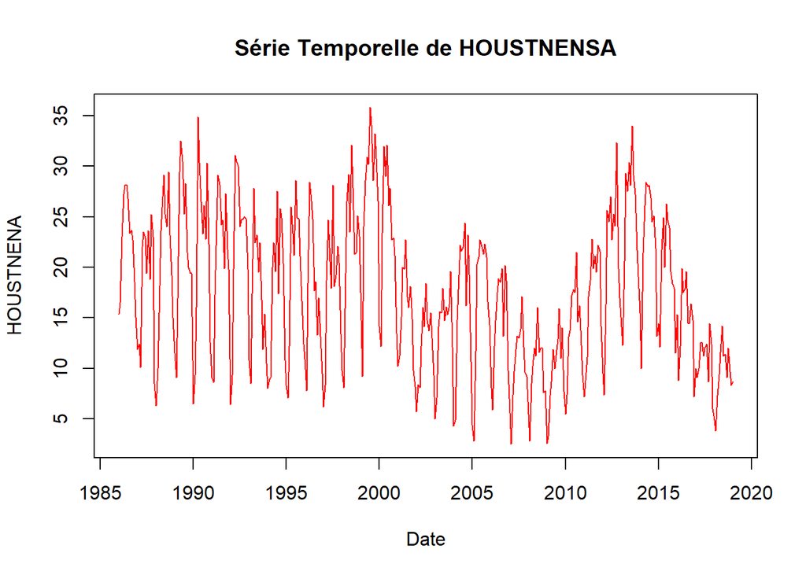

```r
plot(df,
     xlab = "Date", ylab = "HOUSTNENA",
     col = "red", type = "l",main = "Série Temporelle de HOUSTNENSA")
```

–> On remarque que notre serie temporelle n’est pas stationnaire,car on la variance et la moyenne ne sont pas constantes . Alors est elle polynomiale ou marche aleatoire?

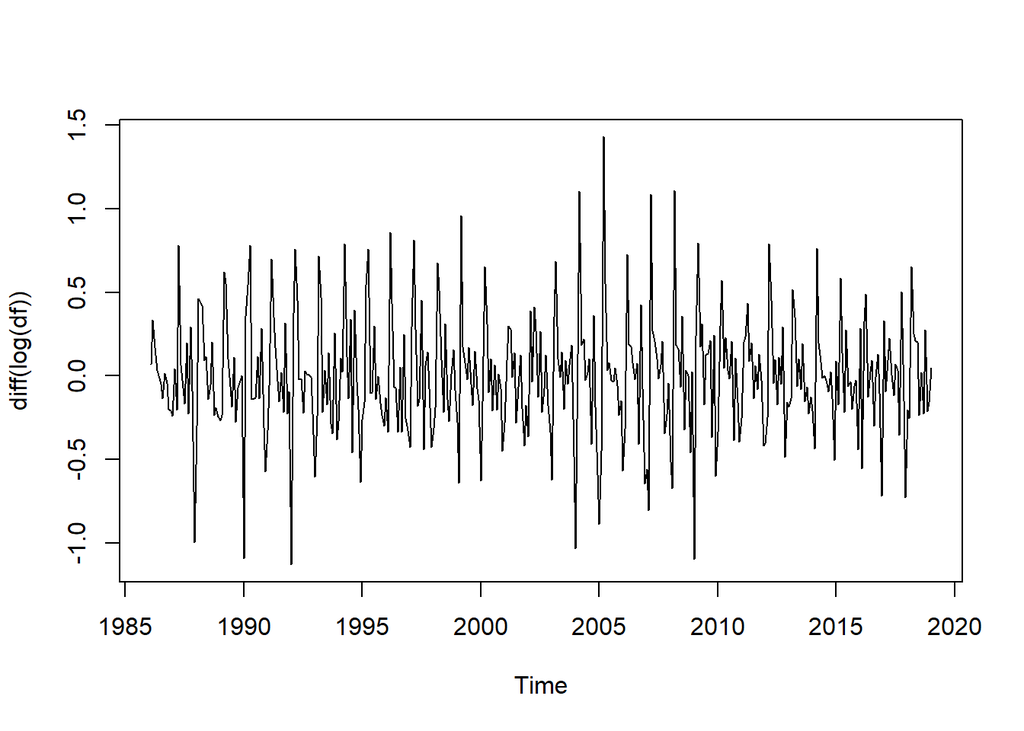

```r
plot(diff(log(df)))
```

–> Les erreurs de notre serie temporelle sont bien du bruit blanc du coup on peut confirmer que notre serie en global est un “Random Walk”.

```r
adf.test(diff(df),alternative = "stationary")
```

```
##
##  Augmented Dickey-Fuller Test
##
## data:  diff(df)
## Dickey-Fuller = -13.299, Lag order = 7, p-value = 0.01
## alternative hypothesis: stationary
```

–> p_value = 0.01 < 0.05 , donc H1 accepté => Les données sont maintenant stationnaires.

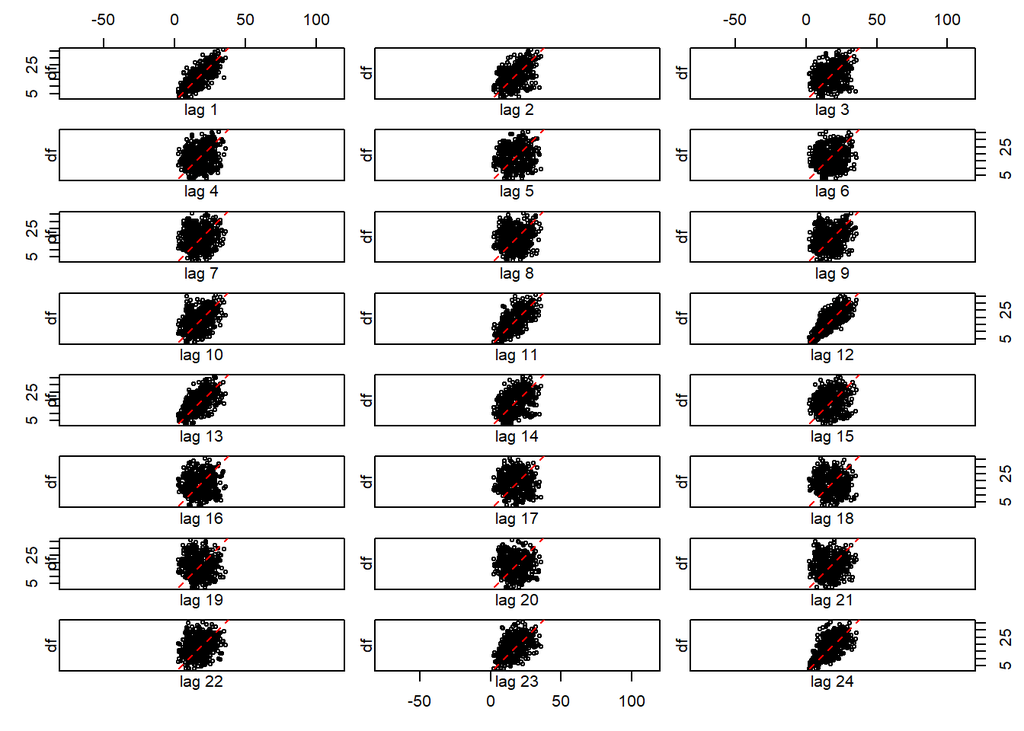

```r
lag.plot(df,lag=24,layout=c(8,3),do.lines=FALSE,diag.col="red",col.main="blue")
```

–>On remarque que notre serie temporelle est Saisoniere, en effet le lag est le meme pour tout les multiples de 12.

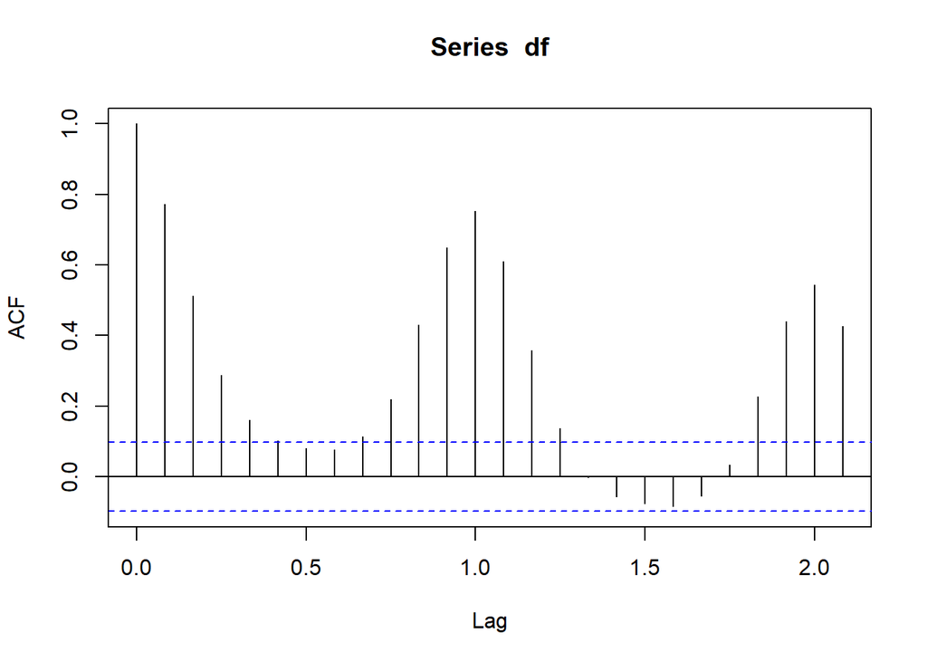

```r
acf(df)
```

–>D’après le test ACF on peut remarquer de plus en plus l’existence de la saisonalité .

```r
test_additive<-decompose(df,type="additive")
```

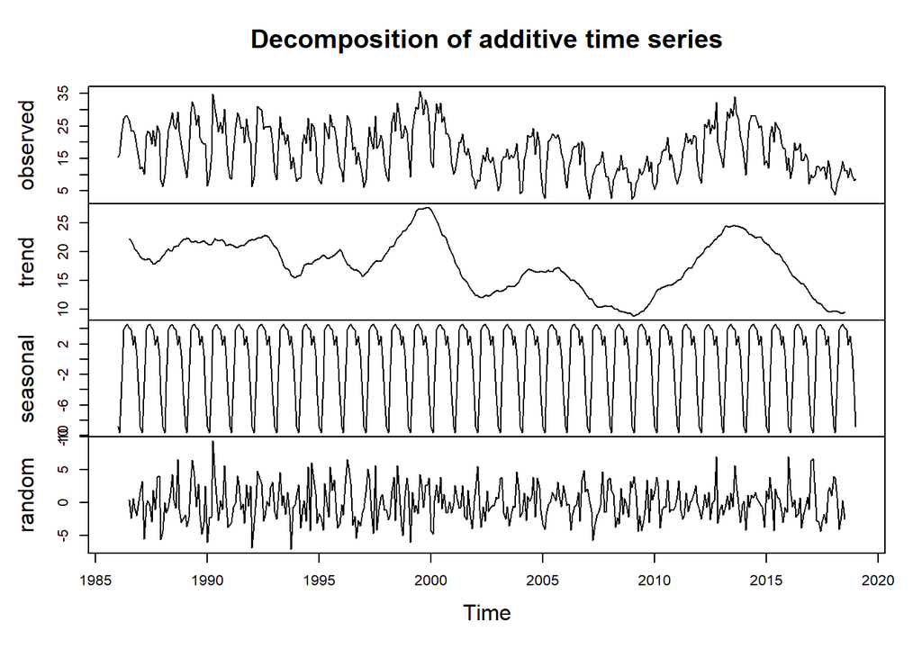

```r
plot(test_additive)
```

–> On peut conclure que notre serie est une marche aleatoire , presentant une haute saisonalité avec differencs pics de tendance significatifs .

```r
test_multiplicative<-decompose(df,type="multiplicative")
```

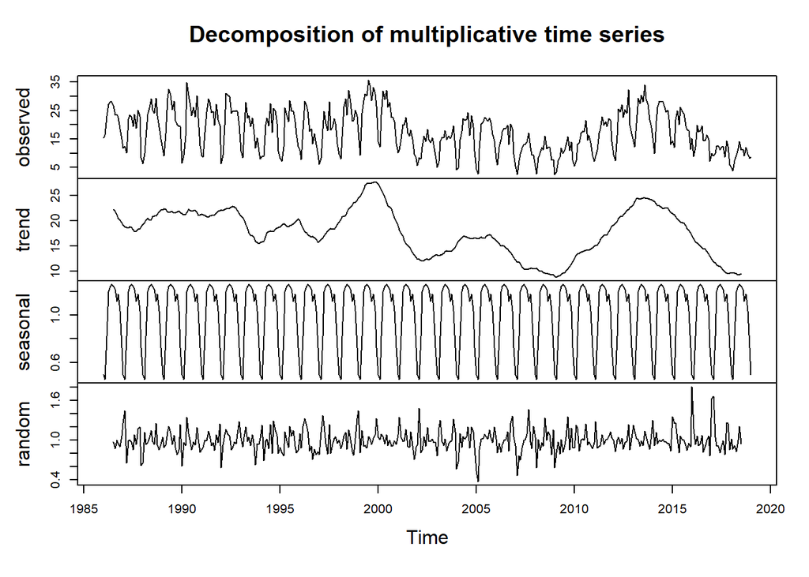

```r
plot(test_multiplicative)
```

–> La meme interpretation precedente.

#PARTIE2 : Ajustement de la série temporel

#Modele de Regression Simple:

```r
t <- 1:length(df)
modele_lineaire <- lm(df~t)
```

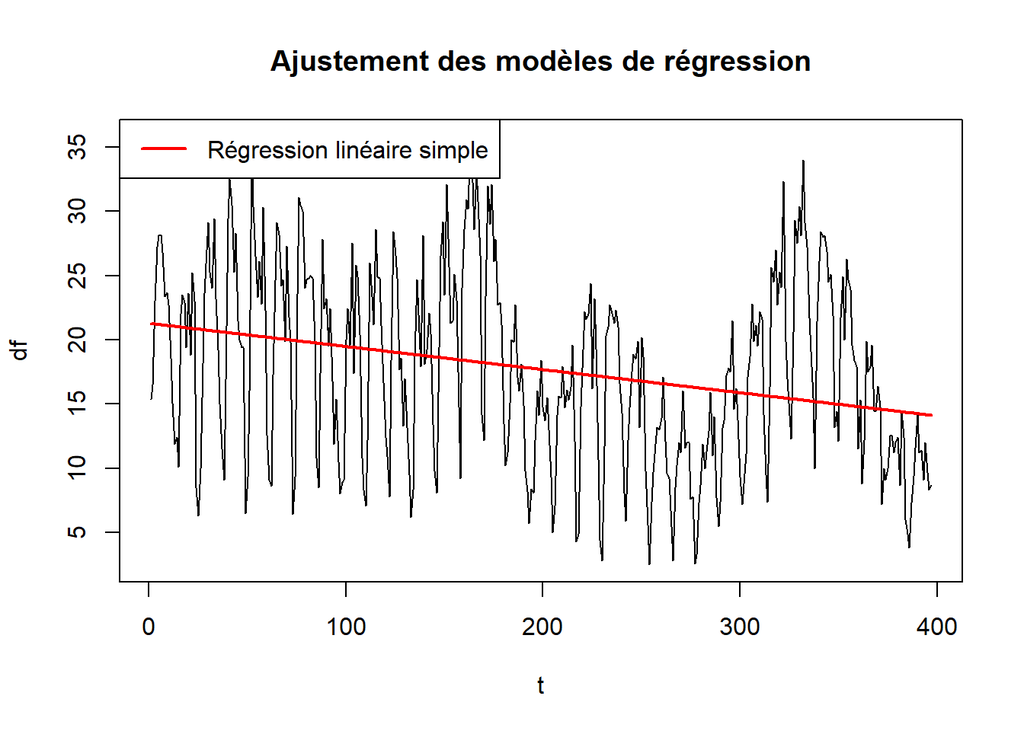

```r
plot(t, df,type='l', main="Ajustement des modèles de régression")
lines(t, modele_lineaire$fitted.values, col="red", lwd=2)
legend("topleft", legend="Régression linéaire simple",
      col="red", lty=1, lwd=2)
```

```r
summary(modele_lineaire)
```

```
##
## Call:
## lm(formula = df ~ t)
##
## Residuals:
##      Min       1Q   Median       3Q      Max
## -14.5206  -5.2079  -0.1394   5.0241  18.7088
##
## Coefficients:
##              Estimate Std. Error t value Pr(>|t|)
## (Intercept) 21.270876   0.716042  29.706  < 2e-16 ***
## t           -0.018011   0.003118  -5.776 1.55e-08 ***
## ---
## Signif. codes:  0 '***' 0.001 '**' 0.01 '*' 0.05 '.' 0.1 ' ' 1
##
## Residual standard error: 7.12 on 395 degrees of freedom
## Multiple R-squared:  0.07789,    Adjusted R-squared:  0.07556
## F-statistic: 33.37 on 1 and 395 DF,  p-value: 1.549e-08
```

#Modele Polynomiale de degrée 2:

```r
degree_2 <- poly(t, 2)


modele_poly_2 <- lm(df ~ degree_2)
```

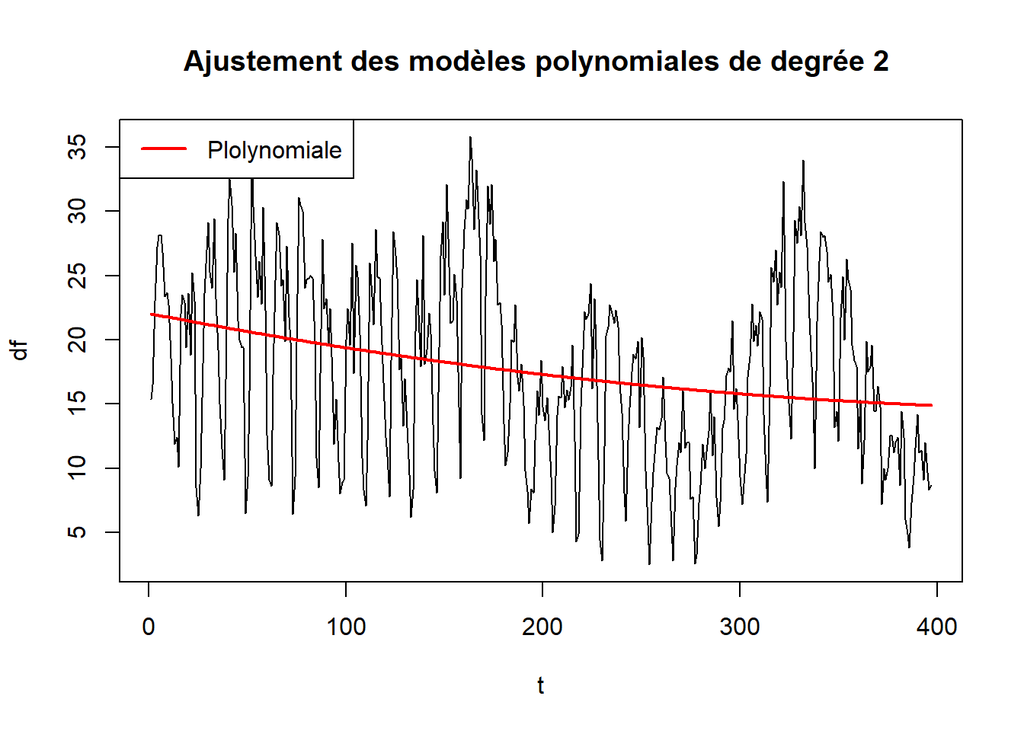

```r
plot(t, df,type='l', main="Ajustement des modèles polynomiales de degrée 2 ")
lines(t, modele_poly_2$fitted.values, col="red", lwd=2)
legend("topleft", legend="Plolynomiale",
      col="red", lty=1, lwd=2)
```

#Modele Polynomiale de degrée 3:

```r
degree_3 <- poly(t, 3)
modele_poly_3 <- lm(df ~ degree_3)
```

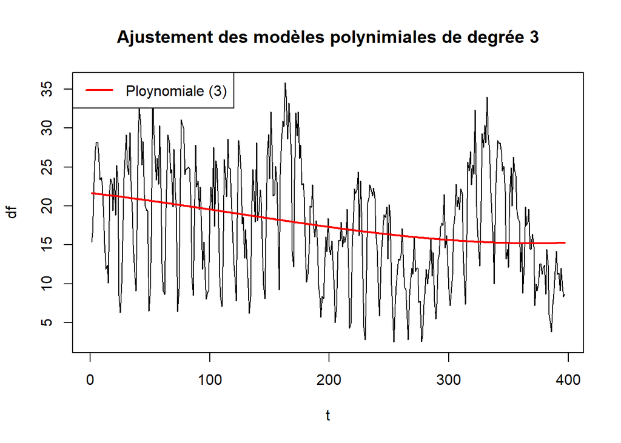

```r
plot(t, df,type='l', main="Ajustement des modèles polynimiales de degrée 3")
lines(t, modele_poly_3$fitted.values, col="red", lwd=2)
legend("topleft", legend="Ploynomiale (3)",
      col="red", lty=1, lwd=2)
```

```r
AIC(modele_lineaire,modele_poly_2,modele_poly_3)
```

```
##                 df      AIC
## modele_lineaire  3 2689.185
## modele_poly_2    4 2690.268
## modele_poly_3    5 2692.100
```

```r
BIC(modele_lineaire,modele_poly_2,modele_poly_3)
```

```
##                 df      BIC
## modele_lineaire  3 2701.137
## modele_poly_2    4 2706.204
## modele_poly_3    5 2712.020
```

–> On peut conclure que:  
*Modèle Linéaire : AIC = 2689.185, BIC = 2701.137*  
Modèle Polynomiale d’Ordre 2 : AIC = 2690.268, BIC = 2706.204  
*Modèle Polynomiale d’Ordre 3 : AIC = 2692.100, BIC = 2712.0

–>le modèle linéaire semble être le meilleur choix, car il présente les valeurs les plus basses d’AIC et de BIC, ce qui indique un meilleur ajustement aux données tout en restant simple. Les modèles polynomiaux d’ordre 2 et 3 présentent des valeurs légèrement plus élevées, ce qui suggère qu’ils pourraient être trop complexes par rapport à l’amélioration marginale de l’ajustement qu’ils offrent.

#Modele ARIMA:

```r
auto.arima(df,seasonal=TRUE)
```

```
## Series: df
## ARIMA(3,0,2)(1,1,2)[12]
##
## Coefficients:
##          ar1      ar2     ar3      ma1     ma2    sar1     sma1    sma2
##       2.1876  -1.4500  0.2569  -1.7810  0.8202  0.1200  -0.8833  0.0059
## s.e.  0.0802   0.1558  0.0798   0.0538  0.0546  0.3859   0.3874  0.3272
##
## sigma^2 = 10.13:  log likelihood = -995.74
## AIC=2009.49   AICc=2009.97   BIC=2045.07
```

```r
modele_arima<- arima(df,order=c(3,0,2),seasonal=list(order=c(1,1,2),period=12))
```

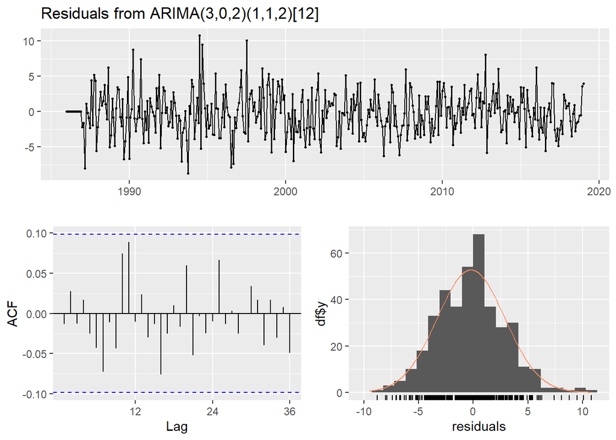

```
##
##  Ljung-Box test
##
## data:  Residuals from ARIMA(3,0,2)(1,1,2)[12]
## Q* = 16.572, df = 16, p-value = 0.4138
##
## Model df: 8.   Total lags used: 24
```

```r
checkresiduals(modele_arima)
```

Conclusion quand au choix du modele adéquat!  
on :  
*Modèle Linéaire : AIC = 2689.185, BIC = 2701.137*  
Modele ARIMA: AIC = 2009.49 , BIC = 2045.07

–>Le modele choisie est : “ARIMA”.

#PARTIE3:Analyse et modélisation des résidus issus de l’ajustement

```r
Box.test(modele_arima$residuals)
```

```
##
##  Box-Pierce test
##
## data:  modele_arima$residuals
## X-squared = 0.068884, df = 1, p-value = 0.793
```

–>Le test de Box-Pierce évalue si les résidus d’un modèle de séries temporelles sont indépendants les uns des autres. Les hypothèses de ce test sont les suivantes :

*Hypothèse nulle (H0) : Les résidus sont indépendants les uns des autres (absence d’autocorrélation).*  
Hypothèse alternative (H1) : Il y a une autocorrélation significative entre les résidus.  
–> p_value=0.793 > 0.05 donc on rejette l’hypothese H1 et on valide H0.

Alors : Absence d’autocorrélation pour les residus, donc homoscedite

```
## <><><><><><><><><><><><><><>
##
## Coefficients:
##          Estimate     SE  t.value p.value
## ar1        2.1885 0.0793  27.6059  0.0000
## ar2       -1.4482 0.1568  -9.2368  0.0000
## ar3        0.2539 0.0813   3.1242  0.0019
## ma1       -1.7872 0.0521 -34.2773  0.0000
## ma2        0.8242 0.0547  15.0689  0.0000
## sar1       0.1493 0.3778   0.3953  0.6928
## sma1      -0.9140 0.3802  -2.4041  0.0167
## sma2       0.0249 0.3231   0.0771  0.9386
## constant  -0.0216 0.0148  -1.4584  0.1456
##
## sigma^2 estimated as 9.851034 on 376 degrees of freedom
##
## AIC = 5.219704  AICc = 5.220951  BIC = 5.322386
##
```

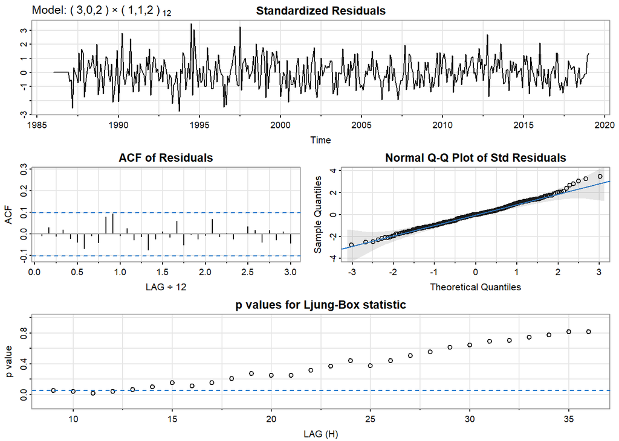

```r
sarima(df,p=3,d=0,q=2,P=1,D=1,Q=2,S=12)
```

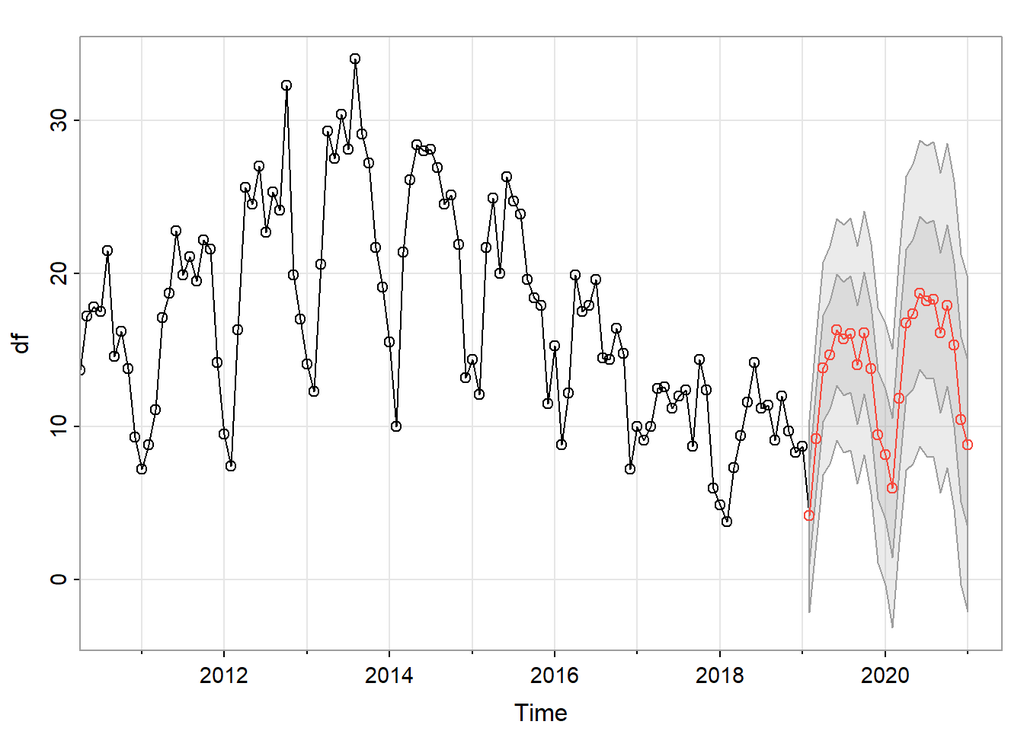

```
## $pred
##            Jan       Feb       Mar       Apr       May       Jun       Jul
## 2019            4.165325  9.206862 13.811833 14.682964 16.337506 15.743837
## 2020  8.177809  5.982082 11.840039 16.773503 17.349755 18.713108 18.193479
## 2021  8.820793
##            Aug       Sep       Oct       Nov       Dec
## 2019 16.054960 14.031481 16.133343 13.766596  9.442344
## 2020 18.309460 16.115827 17.906222 15.328966 10.471558
## 2021
##
## $se
##           Jan      Feb      Mar      Apr      May      Jun      Jul      Aug
## 2019          3.138740 3.381981 3.474764 3.548301 3.624119 3.706192 3.794103
## 2020 4.259715 4.551780 4.693781 4.802400 4.899505 4.989681 5.073586 5.151031
## 2021 5.436414
##           Sep      Oct      Nov      Dec
## 2019 3.886204 3.980573 4.075355 4.168883
## 2020 5.221752 5.285597 5.342556 5.392753
## 2021
```

```r
sarima.for(df,n.ahead = 24,p=3,d=0,q=2,P=1,D=1,Q=2,S=12 )
```